# FAIRmaterials

# Merging two ontologies and specifying some of the metadata:

Lastly we will merge the PV and XRay ontologies. This is accomplished by providing the function a folder path that contains both the PV and XRay ontology sheets. We can also specify some of the metadata included in the outputs.

Merging ontologies in R:

```r
example_folder3 <- system.file("extdata", package = "FAIRmaterials")
FAIRmaterials::process_ontology_files(example_folder3, add_external_onto_info = FALSE, merge_title = "MergedPVandXRay", merge_base_uri = "https://cwrusdle.bitbucket.io/OntologyFilesOwl/Ontology/", merge_version = "1.0")
```

This is the visualization for the two ontologies merged. This visualization from the R package will be saved in the output folder as an SVG:

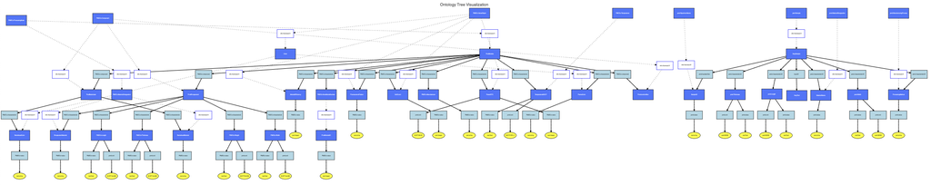

Merged Visualization with Value Types

### Example turtle/owl output from merged ontology:

**Click to expand merged owl file**

[output not shown]

[output cut: 287 more lines]

```

pmd:characteristicOf
    a owl:ObjectProperty ;
    rdfs:domain mds-XraySample:XraySample ;
    rdfs:range mds-XraySample:MaterialName, mds-XraySample:ProcessingMethod, pmd:Length, pmd:Thickness, pmd:Width .

pmd:hasIdentifier
    a owl:ObjectProperty ;
    rdfs:domain mds-XraySample:XraySample ;
    rdfs:range mds-XraySample:SampleID .

pmd:value
    a owl:DatatypeProperty ;
    rdfs:domain mds-XraySample:MaterialName, mds-XraySample:ProcessingMethod, mds-XraySample:SampleID, pmd:Length, pmd:Thickness, pmd:Width ;
    rdfs:range sd:float, sd:string .
```

We can see the ontology metadata was updated and the ontologies were merged.

Merging ontologies in Python:

```python
python -m FAIRmaterials --folder_path /path/to/csv/files/ --merge_title MergedPVandXRay --merge_base_uri https://cwrusdle.bitbucket.io/OntologyFilesOwl/Ontology/ --merge_version 1.0
```

### Example turtle/owl output from merged ontology:

**Click to expand merged owl file**

```
@prefix MergedPVandXRay: <https://cwrusdle.bitbucket.io/OntologyFilesOwl/Ontology/> .
@prefix dcterms: <http://purl.org/dc/terms/> .
@prefix mds-XraySample: <https://cwrusdle.bitbucket.io/xraySample#> .
@prefix mds-pvModule: <https://cwrusdle.bitbucket.io/pvModule#> .
@prefix owl: <http://www.w3.org/2002/07/owl#> .
@prefix pmd: <https://w3id.org/pmd/co/> .
@prefix qudt: <http://qudt.org/2.1/vocab/unit#> .
@prefix rdfs: <http://www.w3.org/2000/01/rdf-schema#> .
@prefix skos: <http://www.w3.org/2004/02/skos/core#> .
@prefix xsd: <http://www.w3.org/2001/XMLSchema#> .

MergedPVandXRay:Ontology a owl:Ontology ;
    dcterms:description "This is the merged ontology of all the input sheets" ;
    dcterms:hasVersion "1.0" ;
    dcterms:title "MergedPVandXRay" ;
    owl:versionInfo "1.0" .

mds-pvModule:EncapsulantMaterial a owl:Class ;
    rdfs:label "EncapsulantMaterial" ;
    rdfs:subClassOf mds-pvModule:PhotovoltaicModuleProperty ;
    skos:altLabel "" ;
    skos:definition "Material of the polymer encapsulant" .

mds-pvModule:ModuleEncapsulant a owl:Class ;
    rdfs:label "ModuleEncapsulant" ;
    rdfs:subClassOf mds-pvModule:PhotovoltaicModuleProperty ;
    skos:altLabel "" ;
    skos:definition "Polymer encapsulant of a module" .

mds-pvModule:ModuleJunctionBox a owl:Class ;
    rdfs:label "ModuleJunctionBox" ;
    rdfs:subClassOf mds-pvModule:PhotovoltaicModuleProperty ;
    skos:altLabel "" ;
    skos:definition "Electrical junction box for connection to the module" .

pmd:characteristicOf a owl:ObjectProperty ;
    rdfs:domain mds-pvModule:PhotovoltaicModule,
        mds-XraySample:XraySample ;
    rdfs:range mds-pvModule:PhotovoltaicModuleProperty,
        mds-pvModule:PhotovoltaicSite,
```

[output cut: 262 more lines]

```
pmd:ProcessingNode a owl:Class ;
    rdfs:label "ProcessingNode" ;
    skos:altLabel "" .

mds-pvModule:ModuleRatingAtReference a owl:Class ;
    rdfs:label "ModuleRatingAtReference" ;
    rdfs:subClassOf mds-pvModule:PhotovoltaicModuleProperty ;
    skos:altLabel "" ;
    skos:definition "Measurements of a module taken at STC and 1000 W/m^2 irradiance" .

mds-pvModule:PhotovoltaicModuleProperty a owl:Class ;
    rdfs:label "PhotovoltaicModuleProperty" ;
    rdfs:subClassOf pmd:ValueObject ;
    skos:altLabel "" ;
    skos:definition "A property of a PV module" .
```

We can see the ontology metadata was updated and the ontologies were merged. We are currently in the process of generating visualizations of merged ontologies.

# Acknowledgment:

This work was supported by the U.S. Department of Energy’s Office of Energy Efficiency and Renewable Energy (EERE) under Solar Energy Technologies Office (SETO) Agreement Numbers DE-EE0009353 and DE-EE0009347, Department of Energy (National Nuclear Security Administration) under Award Number DE-NA0004104 and Contract number B647887, and U.S. National Science Foundation Award under Award Number 2133576.